# Q & K Box 13.2

Mayekar et al (2017) studied some potential determinants of colour (green vs brown) of a tropical butterfly species. A laboratory population was established, and newly hatched larvae were placed in a growth chamber set at either 60% or 85% relative humidity. Resulting pupae were recorded for colour, time to pupation, pupal weight and sex. We will use their data to model green vs brown pupae against the two continuous predictors (time to pupation, pupal weight) and the one categorical predictor (sex). We will only use data from the low humidity treatment as brown pupae were very uncommon at high humidity.

Mayekar, H. V. & Kodandaramaiah, U. (2017). Pupal colour plasticity in a tropical butterfly, *Mycalesis mineus* (Nymphalidae: Satyrinae). *PLoS One*, 12, e0171482.

The paper is [here](https://doi.org/10.1371/journal.pone.0171482), and Figure 1 is an excellent image of the divergent colour phenotypes.

### Preliminaries

First, load the required packages (car, performance, MuMIn)

Import mayekar data file (mayekar.csv)

```r
mayekar <- read.csv("../data/mayekar.csv")
mayekar
```

| rh | colour | timepup | subst | sex | weight | colnum |
| --- | --- | --- | --- | --- | --- | --- |
| low | green | 19 | leaf | male | 0.1590 | 1 |
| low | green | 21 | leaf | female | 0.2511 | 1 |
| low | green | 19 | leaf | male | 0.2289 | 1 |
| low | green | 21 | off-leaf | male | 0.1960 | 1 |
| low | green | 21 | off-leaf | male | 0.1178 | 1 |
| low | green | 21 | off-leaf | female | 0.2312 | 1 |
| low | green | 21 | off-leaf | female | 0.2409 | 1 |
| low | green | 21 | leaf | male | 0.1958 | 1 |
| low | green | 21 | leaf | male | 0.1818 | 1 |
| low | green | 19 | leaf | male | 0.1962 | 1 |

[output cut: 691 more lines]

Create subset of the low-humidity treatment

```r
#select rh = low
mayekar1 <- subset(mayekar, rh=="low")
```

### Do simple plots for cont. predictors

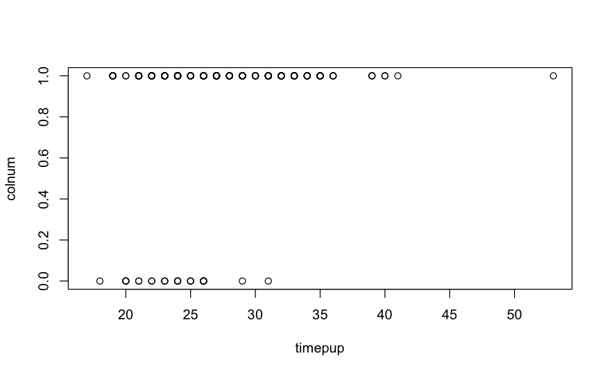

```r
plot(colnum~timepup, data=mayekar1)
```

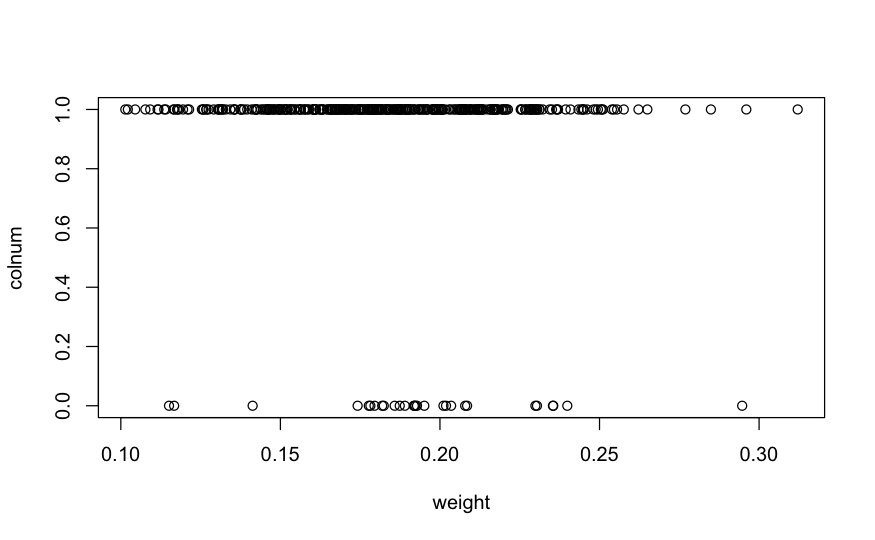

```r
plot(colnum~weight, data=mayekar1)
```

### Fit full glm

```r
mayekar1.glm <- glm(colnum ~ timepup*weight*sex,data=mayekar1,family=binomial)
tidy(mayekar1.glm)
```

| term | estimate | std.error | statistic | p.value |
| --- | --- | --- | --- | --- |
| (Intercept) | -10.323 | 8.458 | -1.220 | 0.222 |
| timepup | 0.490 | 0.338 | 1.450 | 0.147 |
| weight | 39.974 | 43.687 | 0.915 | 0.360 |
| sex1 | 5.965 | 8.458 | 0.705 | 0.481 |
| timepup:weight | -1.461 | 1.763 | -0.828 | 0.407 |
| timepup:sex1 | -0.170 | 0.338 | -0.503 | 0.615 |
| weight:sex1 | -33.946 | 43.687 | -0.777 | 0.437 |
| timepup:weight:sex1 | 0.973 | 1.763 | 0.552 | 0.581 |

```r
glance(mayekar1.glm)
```

| null.deviance | df.null | logLik | AIC | BIC | deviance | df.residual | nobs |
| --- | --- | --- | --- | --- | --- | --- | --- |
| 201 | 387 | -90.5 | 197 | 229 | 181 | 380 | 388 |

```r
AICc(mayekar1.glm)
```

```
[1] 197
```

#### Check collinearity

```r
vif(lm(colnum ~ timepup*weight*sex, data=mayekar1))
```

```
there are higher-order terms (interactions) in this model
consider setting type = 'predictor'; see ?vif
```

```
           timepup             weight                sex     timepup:weight        timepup:sex         weight:sex timepup:weight:sex
              27.9               36.3             1056.6               42.5              964.7              952.8              863.2
```

```r
cor(mayekar1$timepup,mayekar1$weight)
```

```
[1] -0.321
```

```r
aov1 <-aov(timepup~sex, data=mayekar1)
summary(aov1)
```

```
             Df Sum Sq Mean Sq F value Pr(>F)
sex           1     50    49.6    2.33   0.13
Residuals   386   8195    21.2
```

```r
aov2 <- aov(weight~sex, data=mayekar1)
summary(aov2)
```

```
             Df Sum Sq Mean Sq F value  Pr(>F)
sex           1  0.046  0.0459    38.1 1.7e-09 ***
Residuals   386  0.465  0.0012
---
Signif. codes:  0 ‘***’ 0.001 ‘**’ 0.01 ‘*’ 0.05 ‘.’ 0.1 ‘ ’ 1
```

Try centering continuous predictors to reduce collinearity

```r
mayekar1$ctimepup <- scale(mayekar1$timepup, center=TRUE, scale=FALSE)
mayekar1$cweight <- scale(mayekar1$weight, center=TRUE, scale=FALSE)
vif(lm(colnum ~ ctimepup*cweight*sex, data=mayekar1))
```

```
there are higher-order terms (interactions) in this model
consider setting type = 'predictor'; see ?vif
```

```
            ctimepup              cweight                  sex     ctimepup:cweight         ctimepup:sex          cweight:sex ctimepup:cweight:sex
                1.18                 1.42                 1.23                 1.09                 1.17                 1.30                 1.18
```

## Centred predictors

Fit full model

```r
mayekar2.glm <- glm(colnum ~ ctimepup*cweight*sex,data=mayekar1,family=binomial)
summary(mayekar2.glm)
```

```
Call:
glm(formula = colnum ~ ctimepup * cweight * sex, family = binomial,
    data = mayekar1)

Coefficients:
                      Estimate Std. Error z value Pr(>|z|)
(Intercept)            2.98785    0.30434    9.82   <2e-16 ***
ctimepup               0.22009    0.06747    3.26   0.0011 **
cweight                0.67112    8.01128    0.08   0.9332
sex1                  -0.04966    0.30434   -0.16   0.8704
ctimepup:cweight      -1.46097    1.76341   -0.83   0.4074
ctimepup:sex1          0.00968    0.06747    0.14   0.8859
cweight:sex1          -7.77651    8.01128   -0.97   0.3317
ctimepup:cweight:sex1  0.97277    1.76341    0.55   0.5812
---
Signif. codes:  0 ‘***’ 0.001 ‘**’ 0.01 ‘*’ 0.05 ‘.’ 0.1 ‘ ’ 1

(Dispersion parameter for binomial family taken to be 1)

    Null deviance: 201.14  on 387  degrees of freedom
Residual deviance: 180.92  on 380  degrees of freedom
AIC: 196.9

Number of Fisher Scoring iterations: 6
```

```r
AICc(mayekar2.glm)
```

```
[1] 197
```

Fit no interaction model

```r
mayekar3.glm <- glm(colnum ~ ctimepup+cweight+sex,data=mayekar1,family=binomial)
summary(mayekar3.glm)
```

```
Call:
glm(formula = colnum ~ ctimepup + cweight + sex, family = binomial,
    data = mayekar1)

Coefficients:
            Estimate Std. Error z value Pr(>|z|)
(Intercept)    2.921      0.267   10.93  < 2e-16 ***
ctimepup       0.221      0.063    3.50  0.00046 ***
cweight        0.440      6.352    0.07  0.94476
sex1          -0.128      0.217   -0.59  0.55502
---
Signif. codes:  0 ‘***’ 0.001 ‘**’ 0.01 ‘*’ 0.05 ‘.’ 0.1 ‘ ’ 1

(Dispersion parameter for binomial family taken to be 1)

    Null deviance: 201.14  on 387  degrees of freedom
Residual deviance: 183.93  on 384  degrees of freedom
AIC: 191.9

Number of Fisher Scoring iterations: 6
```

```r
AICc(mayekar3.glm)
```

```
[1] 192
```

Compare the two models

```r
anova(mayekar2.glm, mayekar3.glm, test = 'Chisq')
```

```
Analysis of Deviance Table

Model 1: colnum ~ ctimepup * cweight * sex
Model 2: colnum ~ ctimepup + cweight + sex
  Resid. Df Resid. Dev Df Deviance Pr(>Chi)
1       380        181
2       384        184 -4    -3.01     0.56
```

### For interest, see if not centering would have changed our conclusions

#### Fit uncentered no interaction model

```r
mayekar4.glm <- glm(colnum ~ timepup+weight+sex,data=mayekar1,family=binomial)
summary(mayekar4.glm)
```

```
Call:
glm(formula = colnum ~ timepup + weight + sex, family = binomial,
    data = mayekar1)

Coefficients:
            Estimate Std. Error z value Pr(>|z|)
(Intercept)   -3.095      2.254   -1.37  0.16980
timepup        0.221      0.063    3.50  0.00046 ***
weight         0.440      6.352    0.07  0.94476
sex1          -0.128      0.217   -0.59  0.55502
---
Signif. codes:  0 ‘***’ 0.001 ‘**’ 0.01 ‘*’ 0.05 ‘.’ 0.1 ‘ ’ 1

(Dispersion parameter for binomial family taken to be 1)

    Null deviance: 201.14  on 387  degrees of freedom
Residual deviance: 183.93  on 384  degrees of freedom
AIC: 191.9

Number of Fisher Scoring iterations: 6
```

```r
AICc(mayekar4.glm)
```

```
[1] 192
```

Compare to full model (uncentered)

```r
anova(mayekar1.glm, mayekar4.glm, test = 'Chisq')
```

```
Analysis of Deviance Table

Model 1: colnum ~ timepup * weight * sex
Model 2: colnum ~ timepup + weight + sex
  Resid. Df Resid. Dev Df Deviance Pr(>Chi)
1       380        181
2       384        184 -4    -3.01     0.56
```

Same results as for centered analysis

### Focus on fit of no interaction model with uncentered data

```r
summary(mayekar4.glm)
```

```
Call:
glm(formula = colnum ~ timepup + weight + sex, family = binomial,
    data = mayekar1)

Coefficients:
            Estimate Std. Error z value Pr(>|z|)
(Intercept)   -3.095      2.254   -1.37  0.16980
timepup        0.221      0.063    3.50  0.00046 ***
weight         0.440      6.352    0.07  0.94476
sex1          -0.128      0.217   -0.59  0.55502
---
Signif. codes:  0 ‘***’ 0.001 ‘**’ 0.01 ‘*’ 0.05 ‘.’ 0.1 ‘ ’ 1

(Dispersion parameter for binomial family taken to be 1)

    Null deviance: 201.14  on 387  degrees of freedom
Residual deviance: 183.93  on 384  degrees of freedom
AIC: 191.9

Number of Fisher Scoring iterations: 6
```

```r
AICc(mayekar4.glm)
```

```
[1] 192
```

```r
confint(mayekar4.glm)
```

```
              2.5 % 97.5 %
(Intercept)  -7.576  1.299
timepup       0.103  0.350
weight      -12.028 12.963
sex1         -0.563  0.297
```

```r
anova(mayekar4.glm, test = 'Chisq')
```

```
Analysis of Deviance Table

Model: binomial, link: logit

Response: colnum

Terms added sequentially (first to last)

        Df Deviance Resid. Df Resid. Dev Pr(>Chi)
NULL                      387        201
timepup  1    16.84       386        184  4.1e-05 ***
weight   1     0.02       385        184     0.88
sex      1     0.35       384        184     0.55
---
Signif. codes:  0 ‘***’ 0.001 ‘**’ 0.01 ‘*’ 0.05 ‘.’ 0.1 ‘ ’ 1
```

### Create reduced models for lrtests

Remove each of the individual predictors

Note slight differences in P values for continuous predictors - lrtest more reliable

```r
mayekar5.glm <- glm(colnum ~ timepup+weight,data=mayekar1,family=binomial)
mayekar6.glm <- glm(colnum ~ timepup+sex,data=mayekar1,family=binomial)
mayekar7.glm <- glm(colnum ~ weight+sex,data=mayekar1,family=binomial)
lrtest(mayekar5.glm, mayekar4.glm)
```

```
Likelihood ratio test

Model 1: colnum ~ timepup + weight
Model 2: colnum ~ timepup + weight + sex
  #Df LogLik Df Chisq Pr(>Chisq)
1   3  -92.1
2   4  -92.0  1  0.35       0.55
```

```r
lrtest(mayekar6.glm, mayekar4.glm)
```

```
Likelihood ratio test

Model 1: colnum ~ timepup + sex
Model 2: colnum ~ timepup + weight + sex
  #Df LogLik Df Chisq Pr(>Chisq)
1   3    -92
2   4    -92  1     0       0.94
```

```r
lrtest(mayekar7.glm, mayekar4.glm)
```

```
Likelihood ratio test

Model 1: colnum ~ weight + sex
Model 2: colnum ~ timepup + weight + sex
  #Df LogLik Df Chisq Pr(>Chisq)
1   3  -99.4
2   4  -92.0  1  14.8    0.00012 ***
---
Signif. codes:  0 ‘***’ 0.001 ‘**’ 0.01 ‘*’ 0.05 ‘.’ 0.1 ‘ ’ 1
```

#### Check assumptions for the simple (no interaction) model

Get and plot residuals - focus on deviance residuals plot

```r
residuals(mayekar4.glm, type="deviance")
```

[output not shown]

[output cut: 12 more lines]

```
        Test stat Pr(>|Test stat|)
timepup      1.41             0.23
weight       0.01             0.94
sex
```

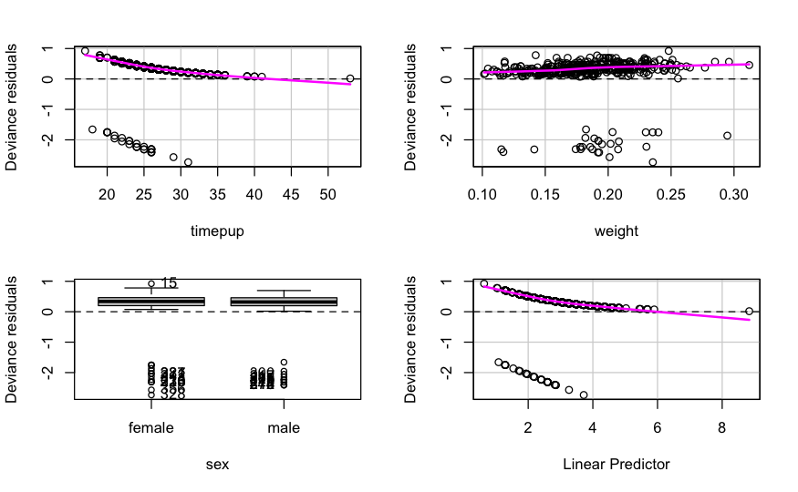

```r
residualPlots(mayekar4.glm, type="deviance")
```

Check influence diagnostics

|  | StudRes | Hat | CookD |
| --- | --- | --- | --- |
| 13 | 0.801 | 0.08202 | 0.00868 |
| 15 | 0.941 | 0.06223 | 0.00936 |
| 493 | -2.796 | 0.00802 | 0.08400 |
| 521 | -2.597 | 0.00549 | 0.03626 |
| 534 | -1.931 | 0.05347 | 0.06952 |

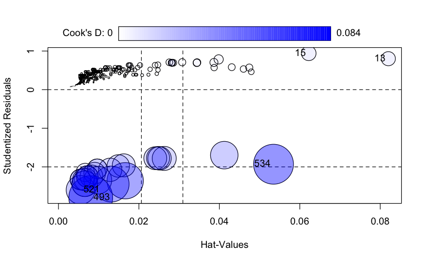

```r
influencePlot(mayekar4.glm)
```

### Examine some alternative assessments

Get odds ratio with CI

```r
exp(coef(mayekar4.glm))
```

```
(Intercept)     timepup      weight        sex1
     0.0453      1.2468      1.5530      0.8795
```

```r
exp(confint.default(mayekar4.glm))
```

```
               2.5 %   97.5 %
(Intercept) 5.46e-04 3.76e+00
timepup     1.10e+00 1.41e+00
weight      6.08e-06 3.96e+05
sex1        5.74e-01 1.35e+00
```

Get added variable plots - hard to interpret

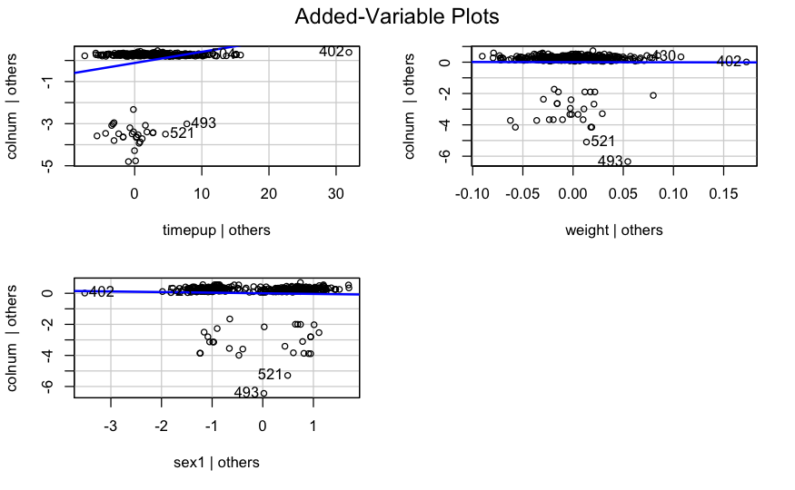

```r
avPlots(mayekar4.glm)
```

Get H-L test and Tjur r<sup>2</sup>

```r
performance_hosmer(mayekar4.glm, n_bins=10)
```

```
# Hosmer-Lemeshow Goodness-of-Fit Test

  Chi-squared: 6.877
           df: 8
      p-value: 0.550
```

```
Summary: model seems to fit well.
```

```r
r2_tjur(mayekar4.glm)
```

```
Tjur's R2
   0.0433
```